# q27clustering and student demographics

A. Katz

9/07/2020

| Q29 | n |
| --- | --- |
| 13 | 915 |
| NA | 771 |
| 5 | 745 |
| 4 | 636 |
| 8 | 351 |
| 3 | 180 |
| 11 | 173 |
| 16 | 151 |
| 10 | 128 |
| 7 | 119 |

[output cut: 9 more lines]

| Q32 | n |
| --- | --- |
| 1 | 1038 |
| 2 | 1122 |
| 3 | 1121 |
| 4 | 702 |
| NA | 622 |

| Q32 | n |
| --- | --- |
| 1 | 72 |
| 2 | 81 |
| 3 | 80 |
| 4 | 75 |
| NA | 463 |

| Q33 | n |
| --- | --- |
| 1 | 1004 |
| 2 | 63 |
| 3 | 143 |
| 4 | 904 |
| 5 | 60 |
| 6 | 68 |
| 7 | 66 |
| 8 | 252 |
| 9 | 419 |
| 10 | 420 |

[output cut: 3 more lines]

| Q33 | n |
| --- | --- |
| 1 | 947 |
| 4 | 835 |
| 10 | 399 |
| 9 | 382 |
| 12 | 351 |
| 8 | 237 |
| 11 | 199 |
| NA | 133 |
| 3 | 119 |
| 6 | 62 |

[output cut: 3 more lines]

| Q37 | n |
| --- | --- |
| 1 | 2985 |
| 2 | 1016 |
| 3 | 29 |
| 4 | 44 |
| 1234 | 1 |
| NA | 530 |

Drop NAs for specific questions and filter out disciplines with fewer than 30 (the cutoff) students in sample

| Q29 | n |
| --- | --- |
| 13 | 644 |
| 5 | 540 |
| 4 | 443 |
| 8 | 243 |
| 16 | 120 |
| 3 | 111 |
| 11 | 111 |
| 7 | 95 |
| 10 | 95 |
| 17 | 81 |

[output cut: 8 more lines]

| Q29 | n |
| --- | --- |
| 13 | 644 |
| 5 | 540 |
| 4 | 443 |
| 8 | 243 |
| 16 | 120 |
| 3 | 111 |
| 11 | 111 |
| 7 | 95 |
| 10 | 95 |
| 17 | 81 |

[output cut: 4 more lines]

Major counts and percentages

| Q29 | major | n | pct_total | cumulat_pct |
| --- | --- | --- | --- | --- |
| 13 | Mec | 644 | 23.97 | 23.97 |
| 5 | Che | 540 | 20.10 | 44.06 |
| 4 | Civ | 443 | 16.49 | 60.55 |
| 8 | Ele | 243 | 9.04 | 69.59 |
| 16 | Softw | 120 | 4.47 | 74.06 |
| 3 | Bio | 111 | 4.13 | 78.19 |
| 11 | Ind | 111 | 4.13 | 82.32 |
| 7 | Comp | 95 | 3.54 | 85.86 |
| 10 | Env/Eco | 95 | 3.54 | 89.39 |
| 17 | Str/Arc | 81 | 3.01 | 92.41 |
| 1 | Aer/Oce | 70 | 2.61 | 95.01 |
| 12 | Mat | 57 | 2.12 | 97.13 |
| 18 | Gen | 42 | 1.56 | 98.70 |
| 6 | Con | 35 | 1.30 | 100.00 |

Gender counts overall

| Q37 | n | pct_total |
| --- | --- | --- |
| 1 | 1973 | 73.43 |
| 2 | 678 | 25.23 |
| 3 | 15 | 0.56 |
| 4 | 21 | 0.78 |

fill in 0s for NAs for specific items (Q1, Q3, Q5)

Drop majors with low counts (below 30 students in sample)

| Q29 | n |
| --- | --- |
| 13 | 618 |
| 5 | 523 |
| 4 | 433 |
| 8 | 240 |
| 16 | 118 |
| 3 | 110 |
| 11 | 108 |
| 7 | 93 |
| 10 | 90 |
| 17 | 78 |

[output cut: 4 more lines]

| major | n |
| --- | --- |
| Mec | 618 |
| Che | 523 |
| Civ | 433 |
| Ele | 240 |
| Softw | 118 |
| Bio | 110 |
| Ind | 108 |
| Comp | 93 |
| Env/Eco | 90 |
| Str/Arc | 78 |

[output cut: 4 more lines]

Drop majors with NA as major

| major | n |
| --- | --- |
| Mec | 618 |
| Che | 523 |
| Civ | 433 |
| Ele | 240 |
| Softw | 118 |
| Bio | 110 |
| Ind | 108 |
| Comp | 93 |
| Env/Eco | 90 |
| Str/Arc | 78 |

[output cut: 4 more lines]

# Clustering Process (two-step process using UMAP + HDBSCAN)

First perform dimension reduction using UMAP

```
##           [,1]      [,2]
## [1,]  15.62332 -15.97910
## [2,]  11.12283 -18.44035
## [3,] -34.20802  18.18004
```

```
## [1]  15.623323  11.122833 -34.208024 -34.419584   6.551877 -34.582958
```

```
## [1] -15.97910 -18.44035  18.18004  18.60377 -23.96864  18.41222
```

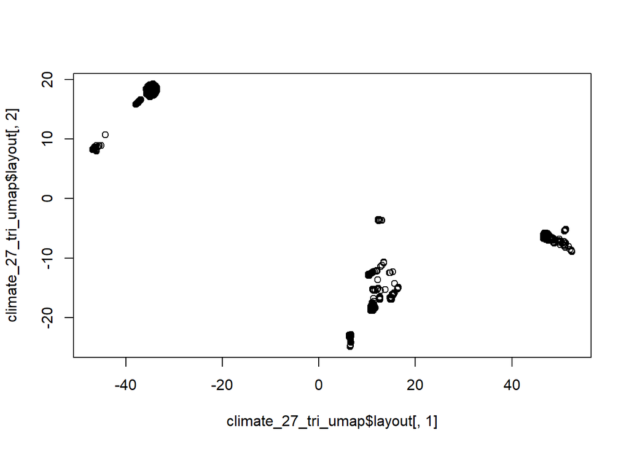

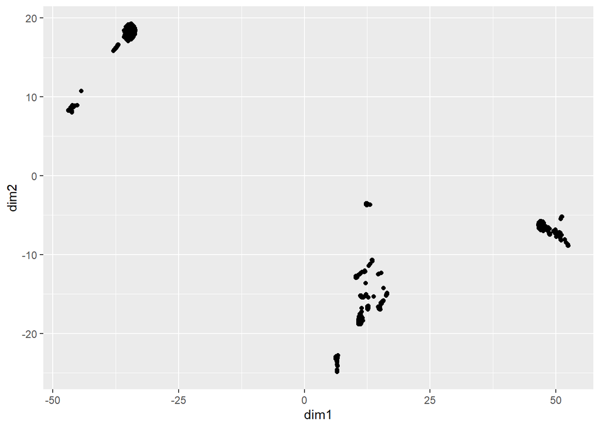

Next, perform clustering with HDBSCAN

```
## HDBSCAN clustering for 2608 objects.
## Parameters: minPts = 120
## The clustering contains 6 cluster(s) and 241 noise points.
##
##    0    1    2    3    4    5    6
##  241 1080  575  175  147  264  126
##
## Available fields: cluster, minPts, cluster_scores, membership_prob,
##                   outlier_scores, hc
```

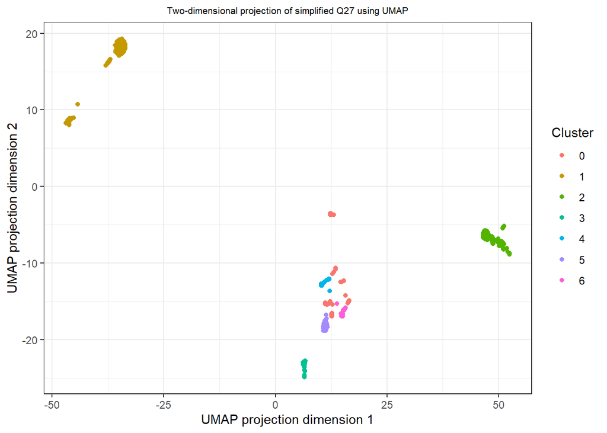

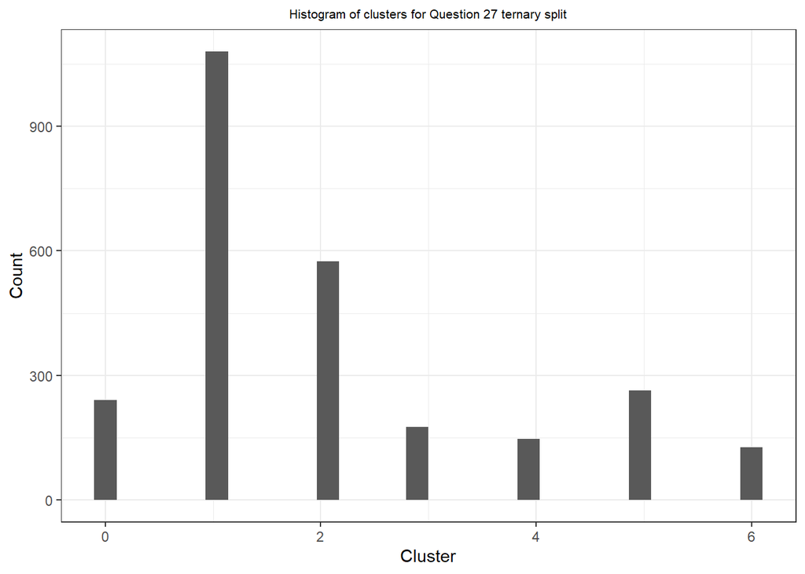

Join the dataframes back together again

| cluster | n |
| --- | --- |
| 1 | 1080 |
| 2 | 575 |
| 5 | 264 |
| 0 | 241 |
| 3 | 175 |
| 4 | 147 |
| 6 | 126 |

## Views of when climate change will affect different groups broken down by cluster assignments

## Looking for patterns in the clusters

# Understanding cluster compositions more

#### First create a dataframe with the rankings for each cluster, where a lower ranking means students in the cluster think climate change will affect more categories sooner.

| cluster_time_rank | cluster | cluster_avg |
| --- | --- | --- |
| 1 | 1 | 0.3861111 |
| 2 | 4 | 3.4557823 |
| 3 | 0 | 4.7551867 |
| 4 | 5 | 5.1401515 |
| 5 | 6 | 7.1349206 |
| 6 | 2 | 9.2434783 |
| 7 | 3 | 17.4000000 |

Set clustering colors for all plots

### Look at distribution of cluster for how when they think each community may be affected by global warming

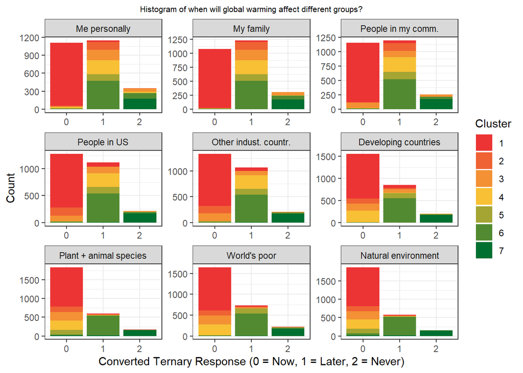

Same information but faceted with clusters

** This is a good plot for seeing that a cluster’s beliefs about effects of global warming on different populations at different times vary in a clear pattern

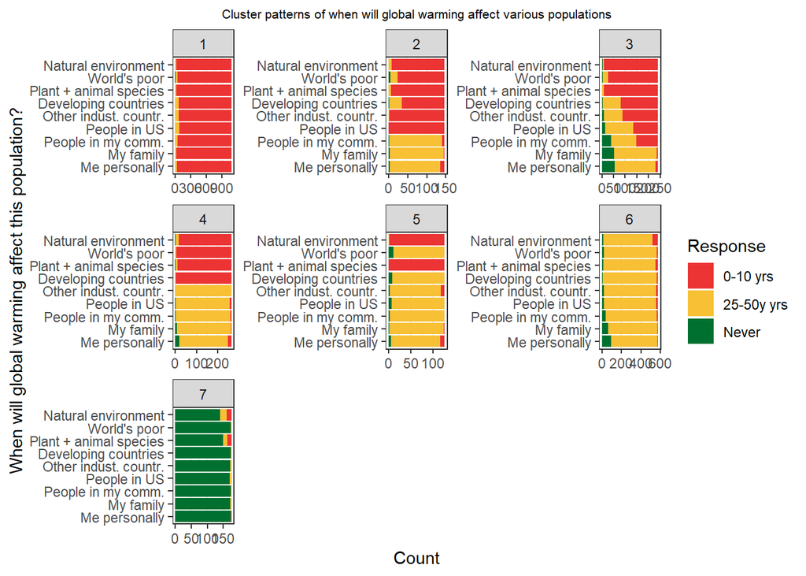

#### Overall count for clusters

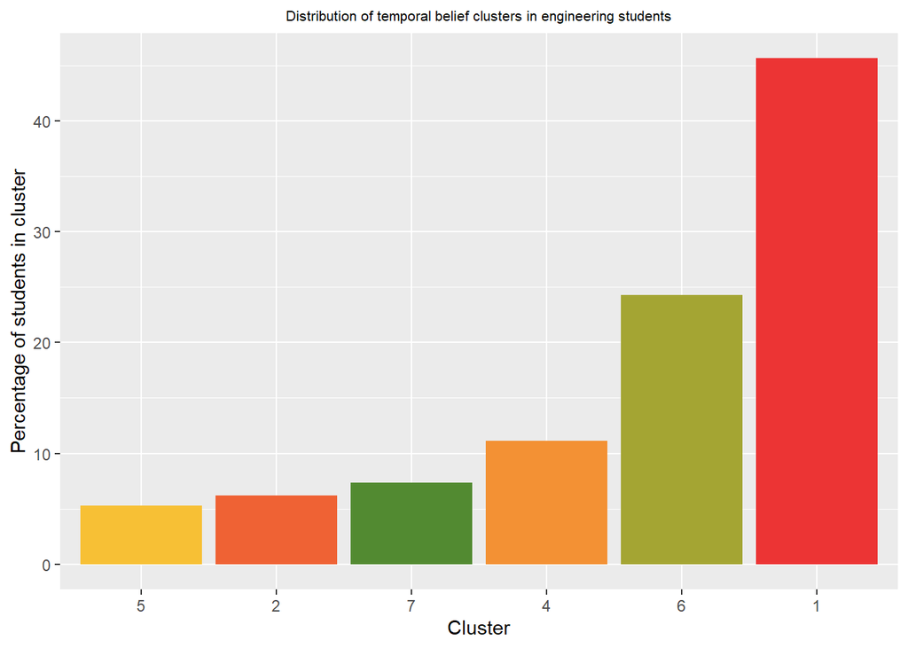

Broken plot

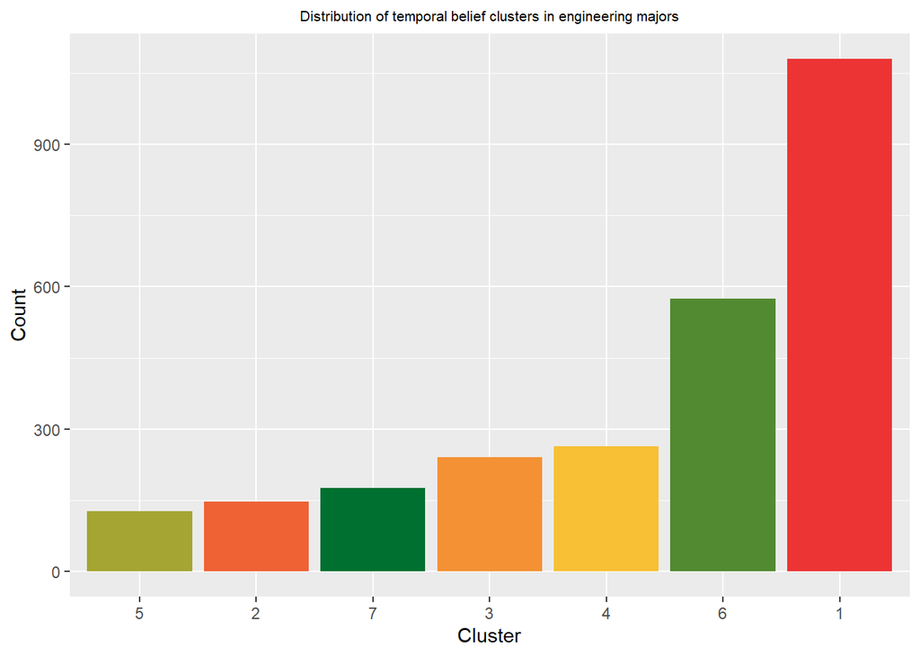

## Looking at major composition for each cluster

#### Histogram of Q27 cluster distribution by major

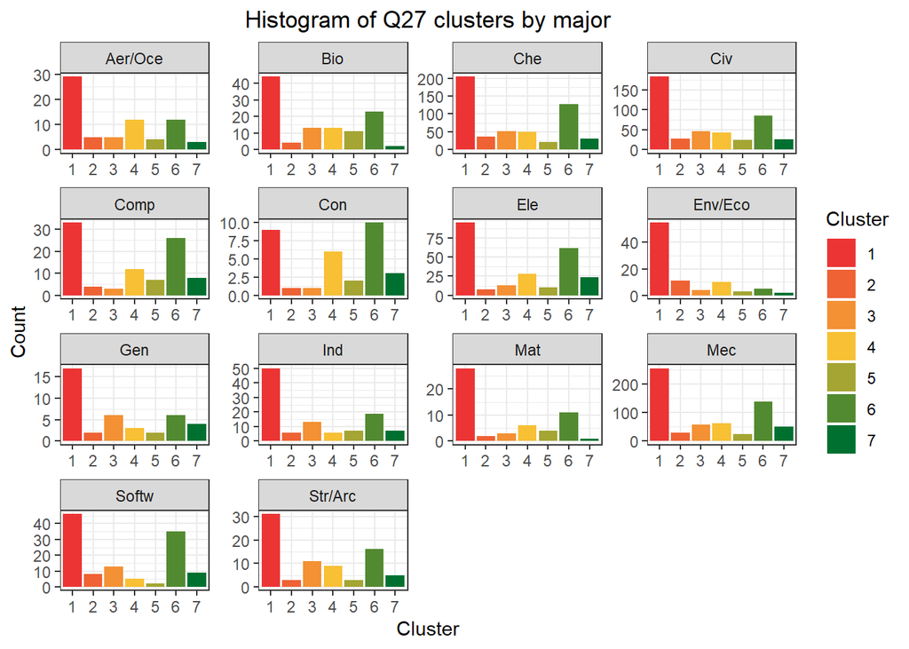

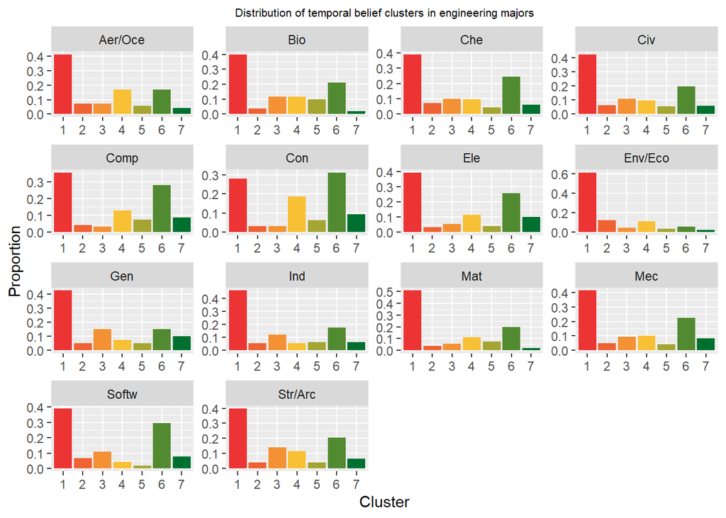

Ordrered plot of distribution of clusters for each major

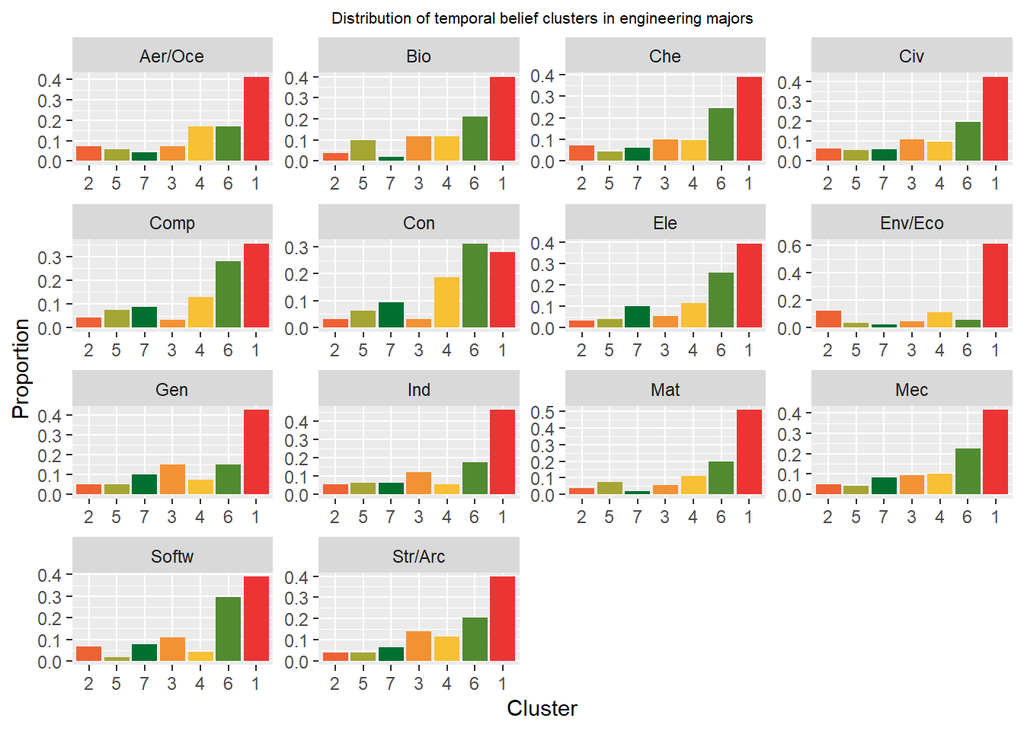

#### Distribution of majors within each cluster

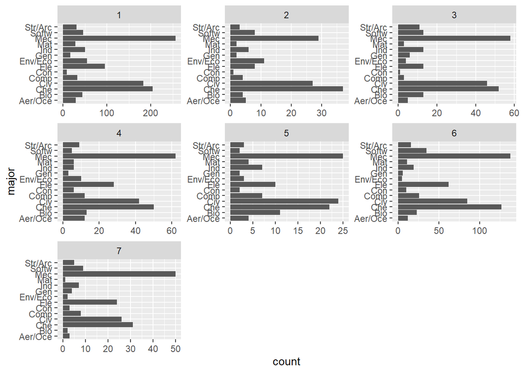

Set colors for majors for all plots

Plotting the proportion of major in each cluster, ordered within each cluster in decreasing proportion

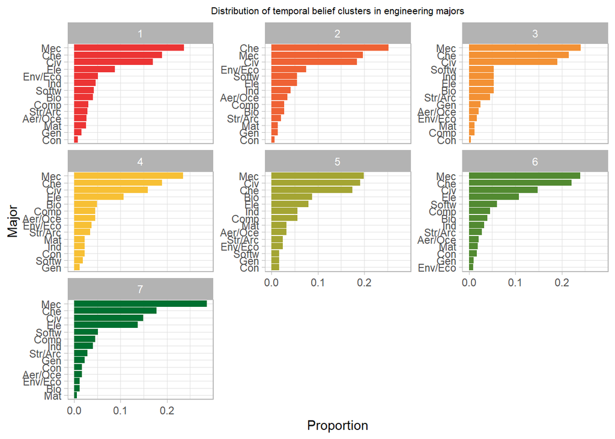

Alternative approach to plotting the proportion of major in each cluster

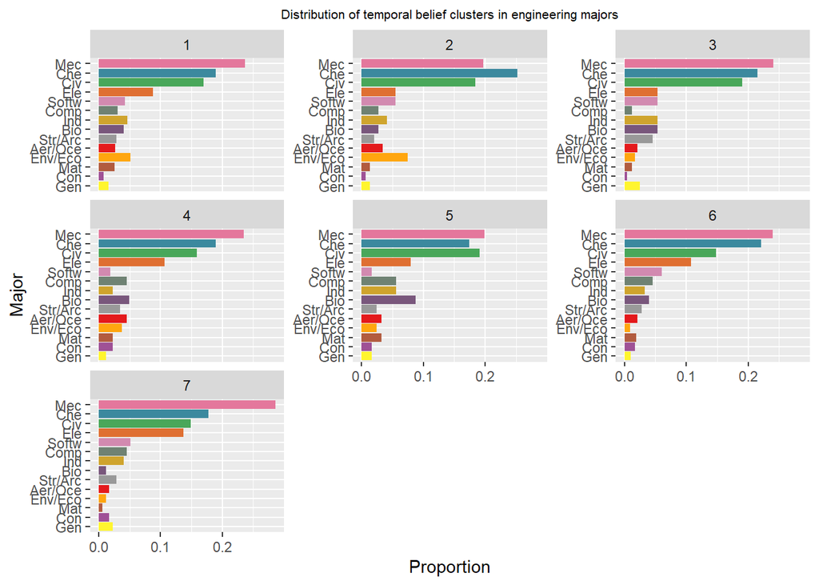

### Distribution of cluster within each gender group

Proportion of gender in each cluster

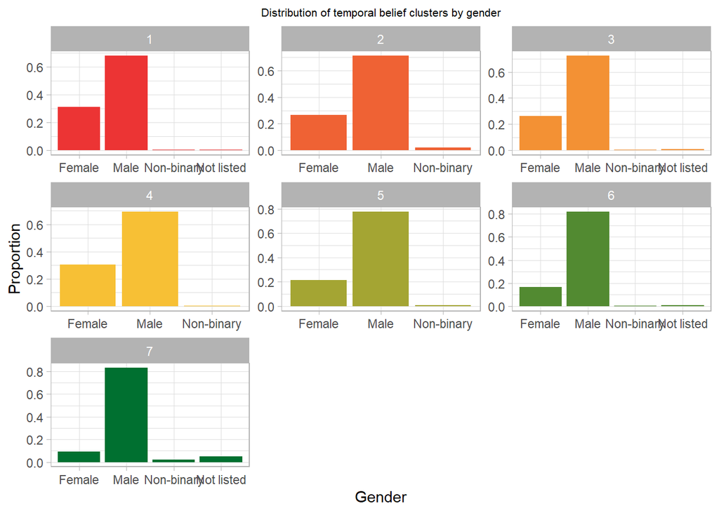

Counts of gender in each group

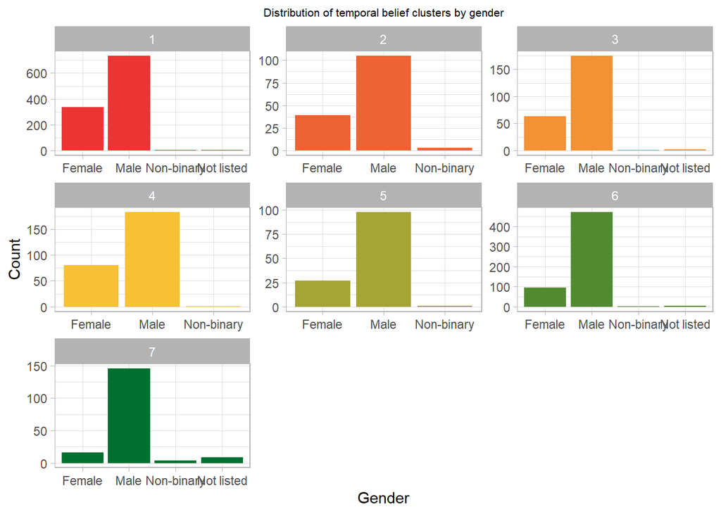

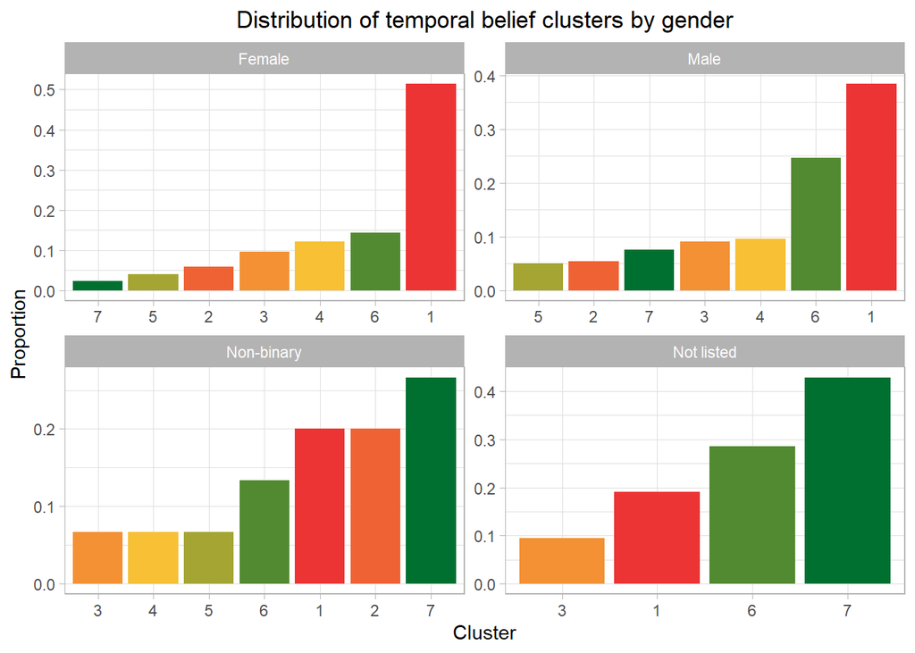

#### non-parametric test of gender distribution in clusters

| gender | n |
| --- | --- |
| Female | 658 |
| Male | 1914 |
| Non-binary | 15 |
| Not listed | 21 |

```
##
##     Female Male Non-binary Not listed
##   1    338  735          3          4
##   2     39  105          3          0
##   3     63  175          1          2
##   4     80  183          1          0
##   5     27   98          1          0
##   6     95  472          2          6
##   7     16  146          4          9
```

```
##
##  Pearson's Chi-squared test
##
## data:  cont_table_gender
## X-squared = 133.24, df = 18, p-value < 2.2e-16
```

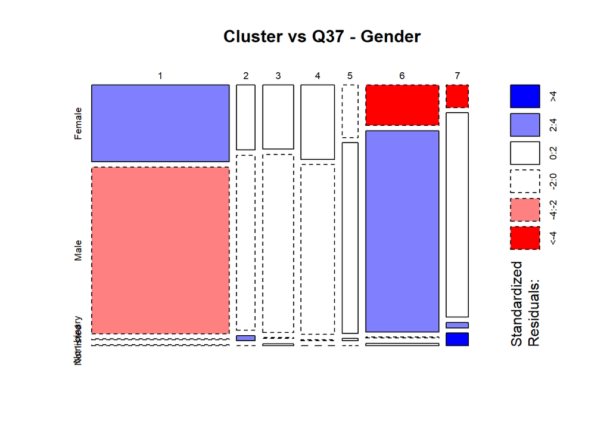

### Distribution of cluster within each political affiliation

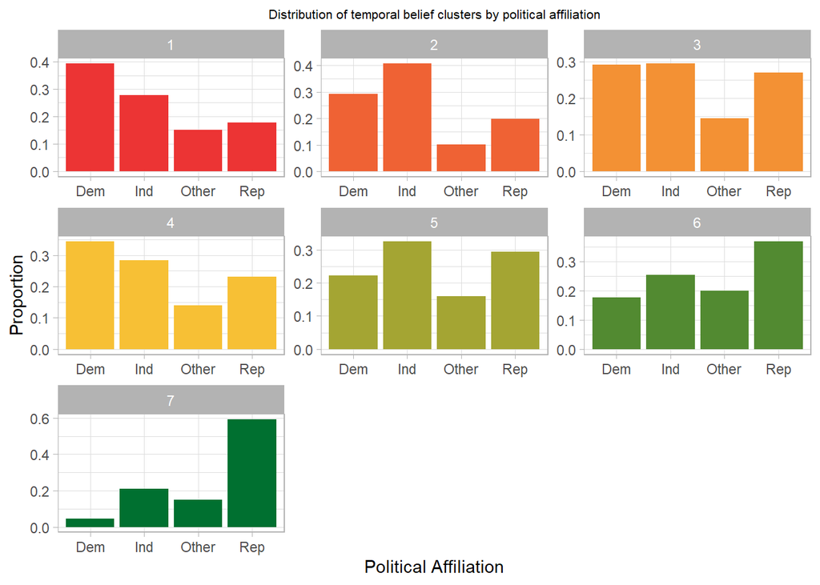

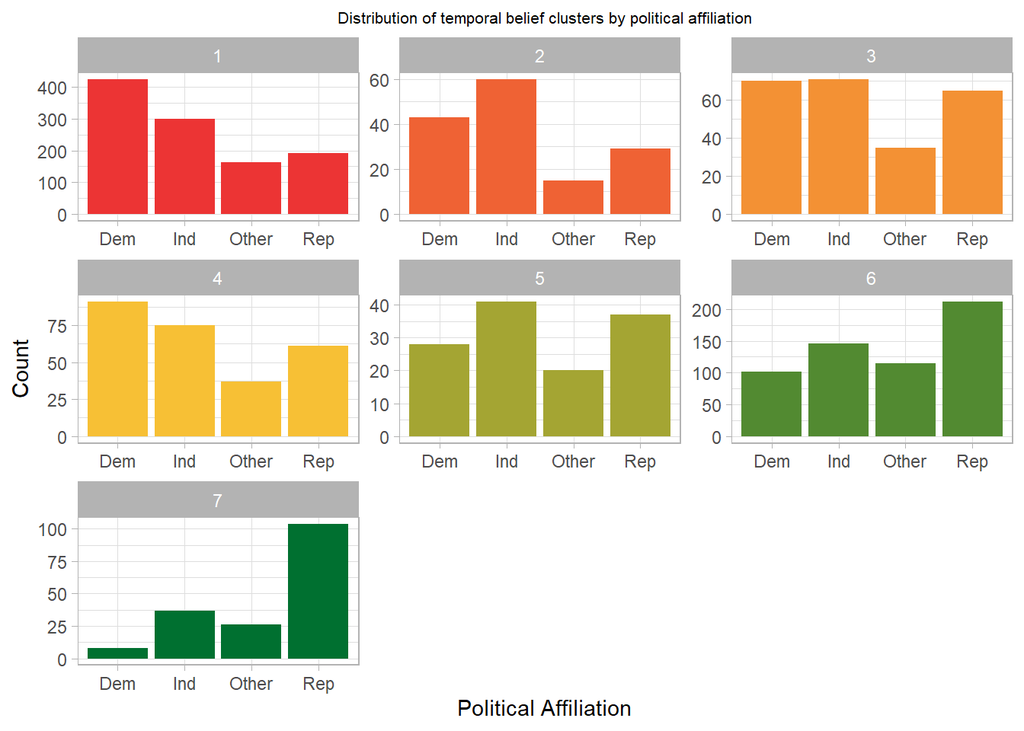

Proportion of cluster for each group

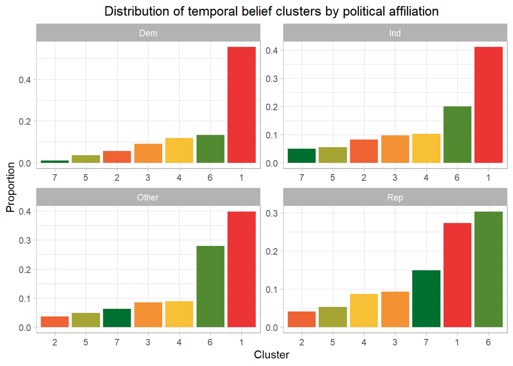

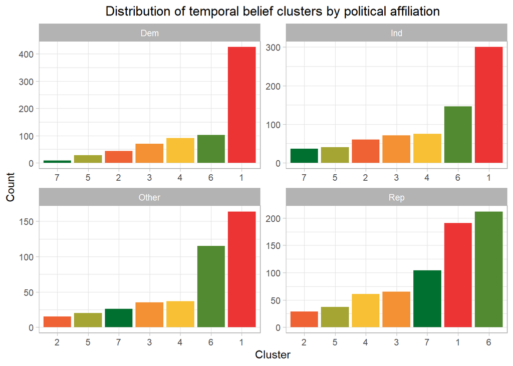

#### Distribution of political affiliation in clusters

| poli_aff | n |
| --- | --- |
| Dem | 767 |
| Ind | 730 |
| Other | 412 |
| Rep | 699 |

```
##
##     Dem Ind Other Rep
##   1 425 300   164 191
##   2  43  60    15  29
##   3  70  71    35  65
##   4  91  75    37  61
##   5  28  41    20  37
##   6 102 146   115 212
##   7   8  37    26 104
```

```
##
##  Pearson's Chi-squared test
##
## data:  cont_table_poli
## X-squared = 257.89, df = 18, p-value < 2.2e-16
```

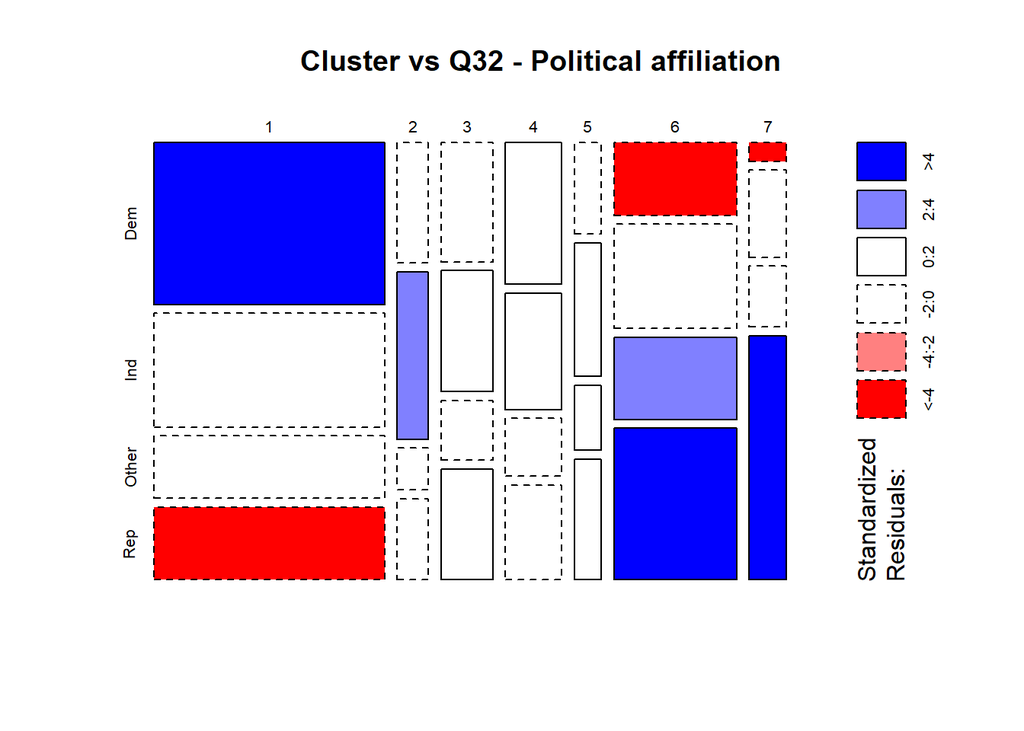

## Distribution of clusters among races/ethnicities

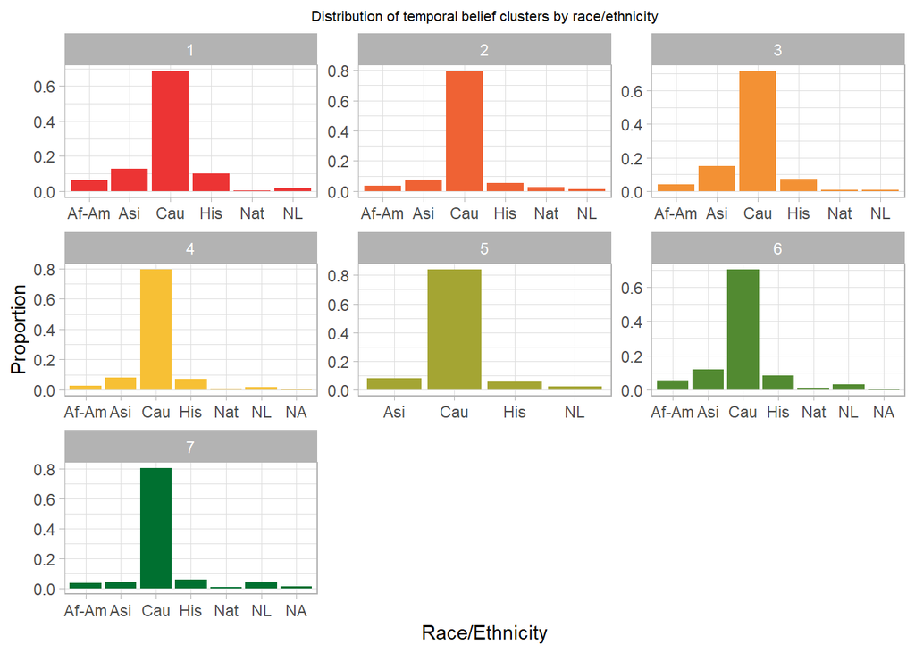

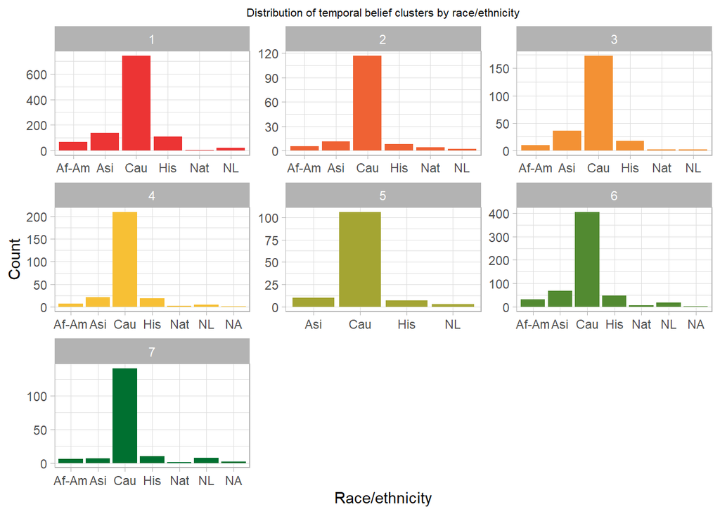

Proportion of cluster for each group

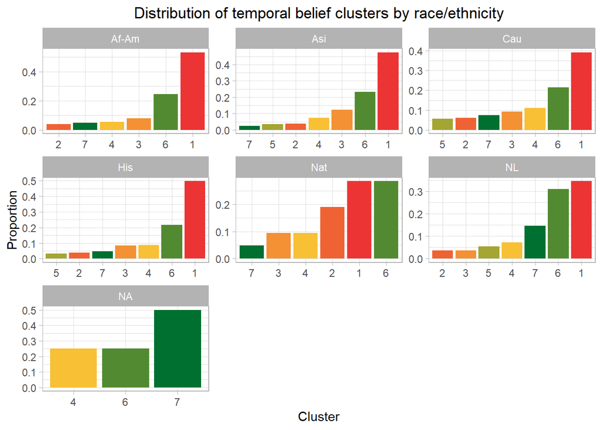

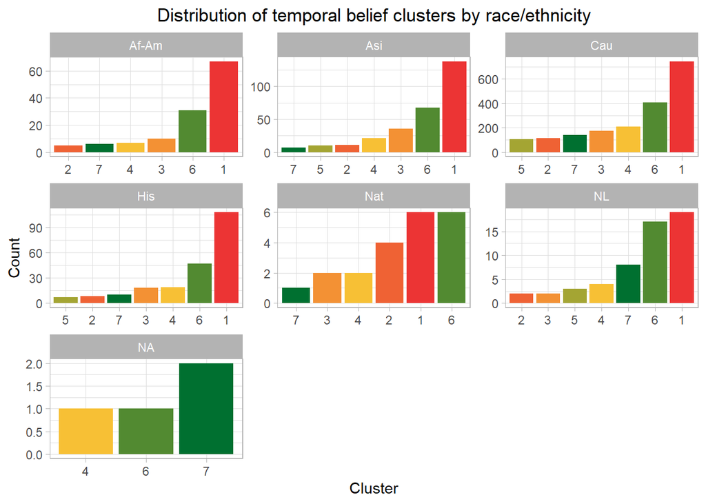

#### Distribution of races/ethnicities in clusters

| race_eth | n |
| --- | --- |
| Af-Am | 126 |
| Asi | 291 |
| Cau | 1894 |
| His | 217 |
| Nat | 21 |
| NL | 55 |
| NA | 4 |

```
##
##     Af-Am Asi Cau His Nat  NL
##   1    67 138 742 108   6  19
##   2     5  11 117   8   4   2
##   3    10  36 173  18   2   2
##   4     7  21 210  19   2   4
##   5     0  10 106   7   0   3
##   6    31  68 405  47   6  17
##   7     6   7 141  10   1   8
```

```
##
##  Pearson's Chi-squared test
##
## data:  cont_table
## X-squared = 71.217, df = 30, p-value = 3.33e-05
```

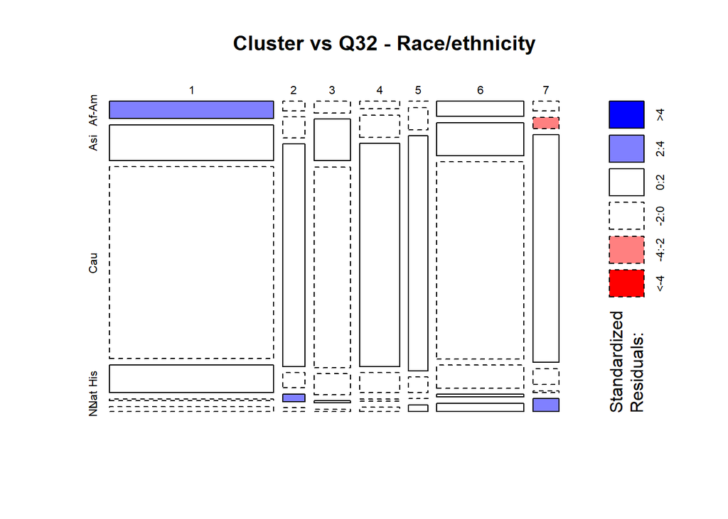

### Distribution of clusters by year in school – not worth doing since most are 4th, 5th, or 6th year

| Q30 | n |
| --- | --- |
| 1 | 1 |
| 2 | 2 |
| 3 | 33 |
| 4 | 1664 |
| 5 | 743 |
| 6 | 164 |
| NA | 1 |

### Look at cluster and grade distributions

| Q31 | n |
| --- | --- |
| 1 | 546 |
| 2 | 547 |
| 3 | 519 |
| 4 | 524 |
| 5 | 251 |
| 6 | 126 |
| 7 | 38 |
| 8 | 2 |
| 9 | 2 |
| NA | 53 |

#### Chi square test of grade distribution by cluster membership

Observation: no evidence to support statistical association (probably a good thing)

```
##
##       A  A-   B  B-  B+   C  C-  C+ D or lower
##   1 215 213 214 112 221  24   1  57          0
##   2  37  30  30  15  25   0   0   7          0
##   3  49  49  50  20  50   4   0  16          0
##   4  57  58  54  27  52   2   0   7          0
##   5  31  36  33   5  17   0   0   4          0
##   6 125 129 115  51 113   3   1  24          1
##   7  32  32  28  21  41   5   0  11          1
```

```
##
##  Pearson's Chi-squared test
##
## data:  cont_table
## X-squared = 55.003, df = 48, p-value = 0.2266
```

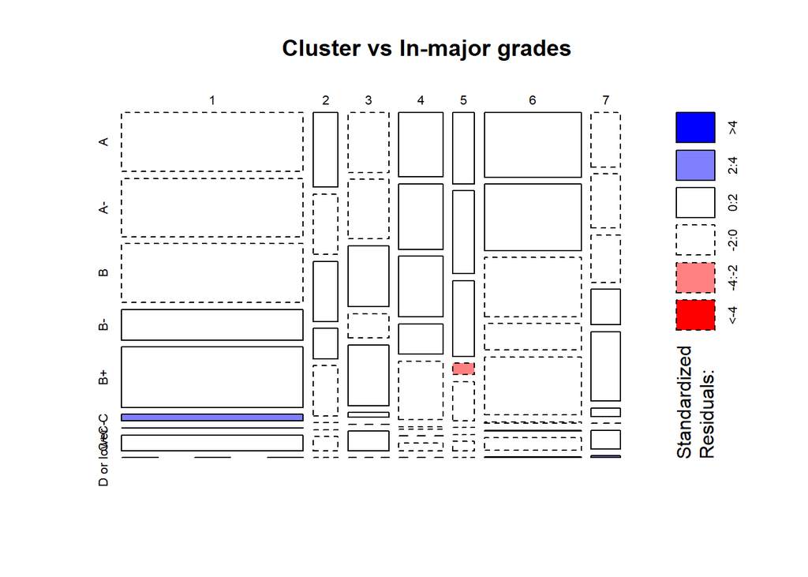

# Distribution of clusters by geographic location

This includes student hometown zipcodes, student hometown census region, student hometown census division, student school census region, and student school census division

```
## [1] 2608
```

```
## [1] 2608
```

| zip | cluster | cluster_time_rank | value |
| --- | --- | --- | --- |
| 0 | 2 | 6 | 1 |
| 0 | 5 | 4 | 1 |
| 4 | 0 | 3 | 1 |
| 8 | 2 | 6 | 1 |
| 860 | 1 | 1 | 1 |
| 1794 | 1 | 1 | 1 |
| 2821 | 1 | 1 | 1 |
| 4130 | 1 | 1 | 1 |
| 6550 | 1 | 1 | 1 |
| 6600 | 1 | 1 | 1 |

[output cut: 18 more lines]

```
## [1] 2561
```

## Geographic region analysis for clusters

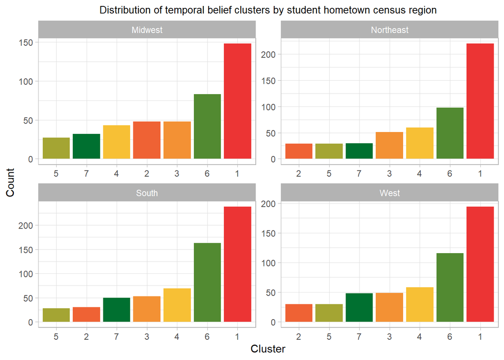

Same plot without reordering by size

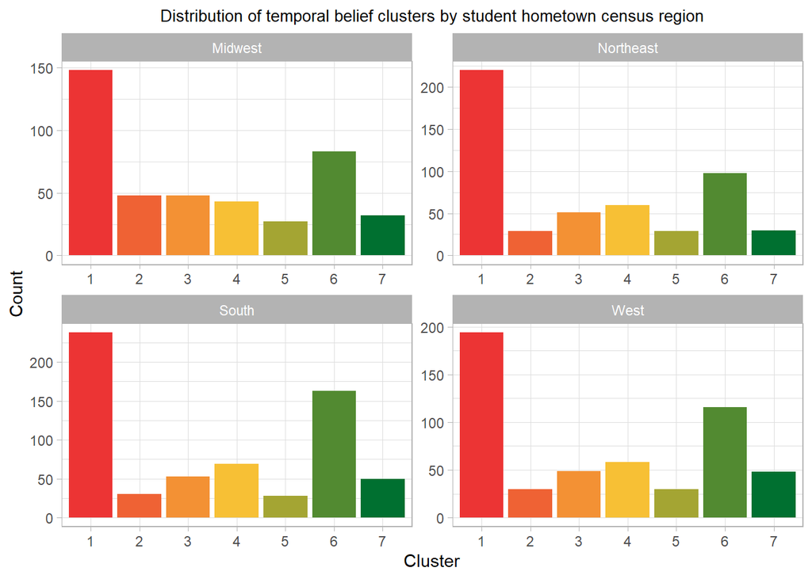

| region_name | n |
| --- | --- |
| Midwest | 429 |
| Northeast | 517 |
| South | 631 |
| West | 525 |

```
##
##     Midwest Northeast South West
##   1     148       220   238  194
##   2      48        29    30   30
##   3      48        51    53   49
##   4      43        60    69   58
##   5      27        29    28   30
##   6      83        98   163  116
##   7      32        30    50   48
```

```
##
##  Pearson's Chi-squared test
##
## data:  cont_table_region
## X-squared = 39.18, df = 18, p-value = 0.002695
```

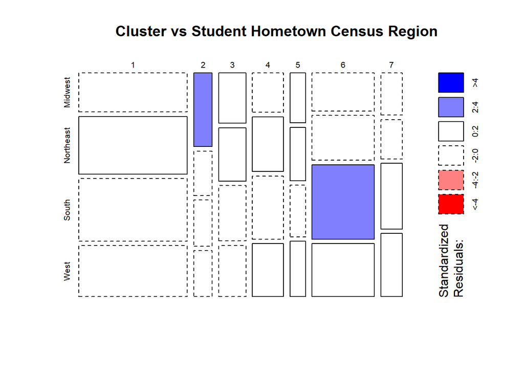

##### Same analysis as above but using census division instead of census region

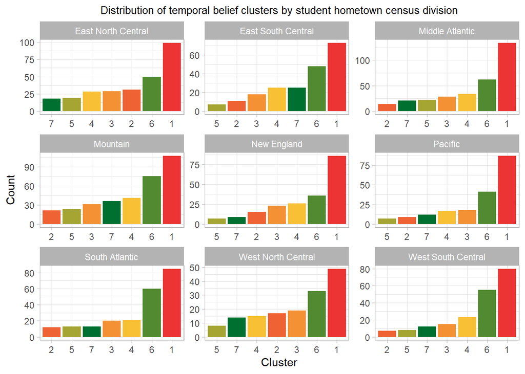

Same plot for census division without reordering by size

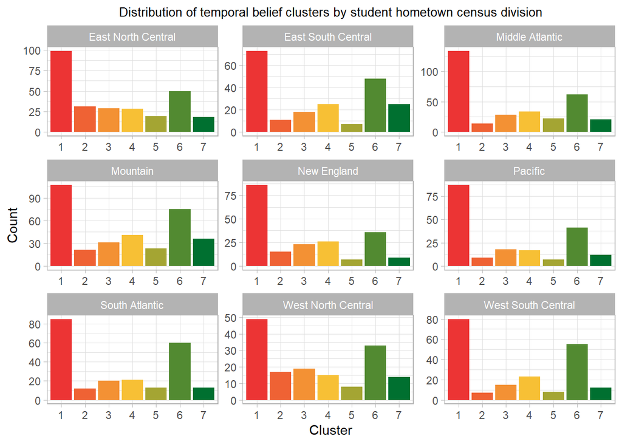

| division_name | n |
| --- | --- |
| East North Central | 274 |
| East South Central | 207 |
| Middle Atlantic | 315 |
| Mountain | 334 |
| New England | 202 |
| Pacific | 191 |
| South Atlantic | 224 |
| West North Central | 155 |
| West South Central | 200 |

```
##
##     East North Central East South Central Middle Atlantic Mountain New England
##   1                 99                 73             134      107          86
##   2                 31                 11              14       21          15
##   3                 29                 18              28       31          23
##   4                 28                 25              34       41          26
##   5                 19                  7              22       23           7
##   6                 50                 48              62       75          36
##   7                 18                 25              21       36           9
##
##     Pacific South Atlantic West North Central West South Central
##   1      87             85                 49                 80
##   2       9             12                 17                  7
##   3      18             20                 19                 15
##   4      17             21                 15                 23
##   5       7             13                  8                  8
##   6      41             60                 33                 55
##   7      12             13                 14                 12
```

```
##
##  Pearson's Chi-squared test
##
## data:  cont_table_division
## X-squared = 73.386, df = 48, p-value = 0.01063
```

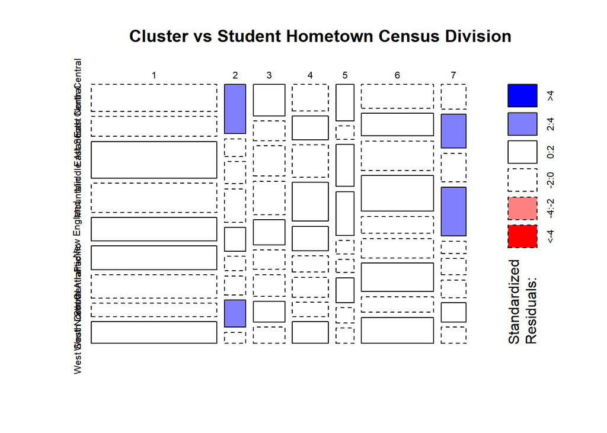

### Map of cluster distributions

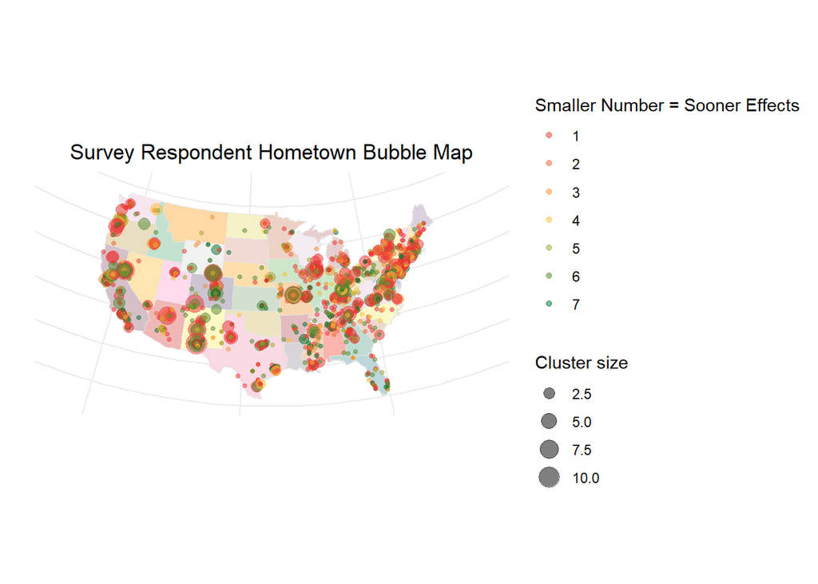

## School and academic experiences by cluster

Distribution of clusters among different types of universities – Carnegie classification

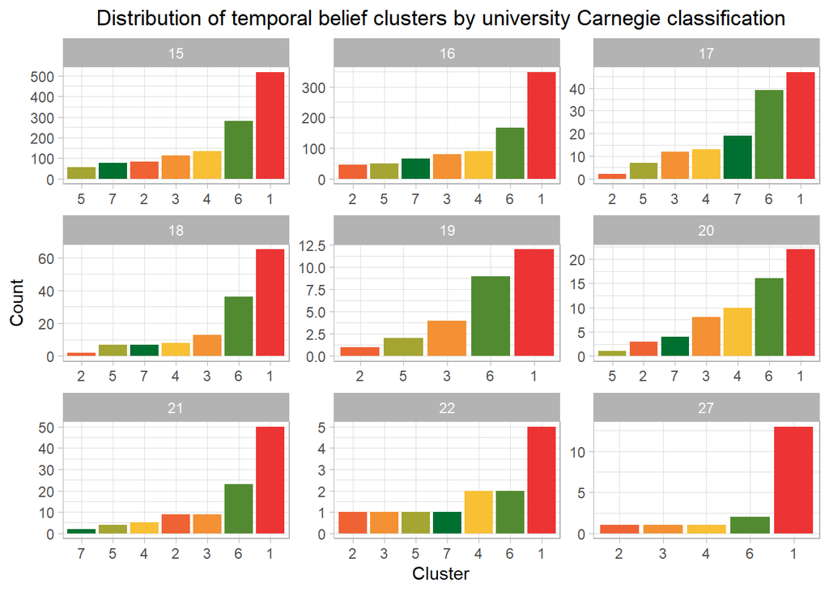

Distribution among schools in census regions and census divisions

##### Distribution of clusters among census region location of schools

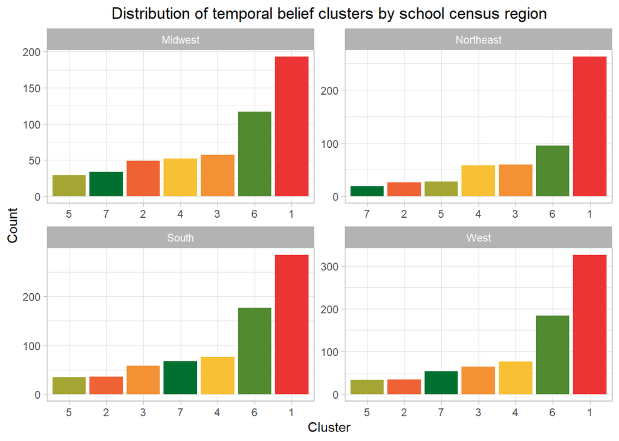

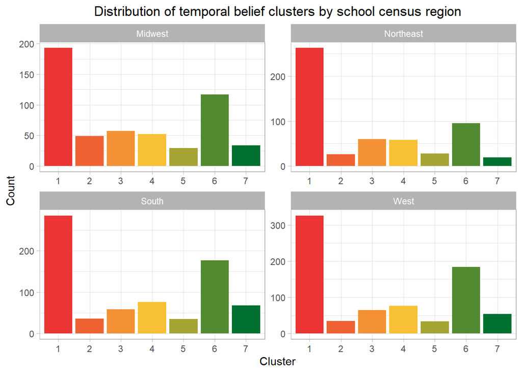

Chi square test of cluster by school census region location

| region_name_school | n |
| --- | --- |
| Midwest | 531 |
| Northeast | 549 |
| South | 735 |
| West | 775 |

```
##
##     Midwest Northeast South West
##   1     193       263   285  326
##   2      49        26    36   35
##   3      57        60    58   65
##   4      52        58    76   77
##   5      29        28    35   34
##   6     117        95   177  184
##   7      34        19    68   54
```

```
##
##  Pearson's Chi-squared test
##
## data:  cont_table_region
## X-squared = 55.369, df = 18, p-value = 1.121e-05
```

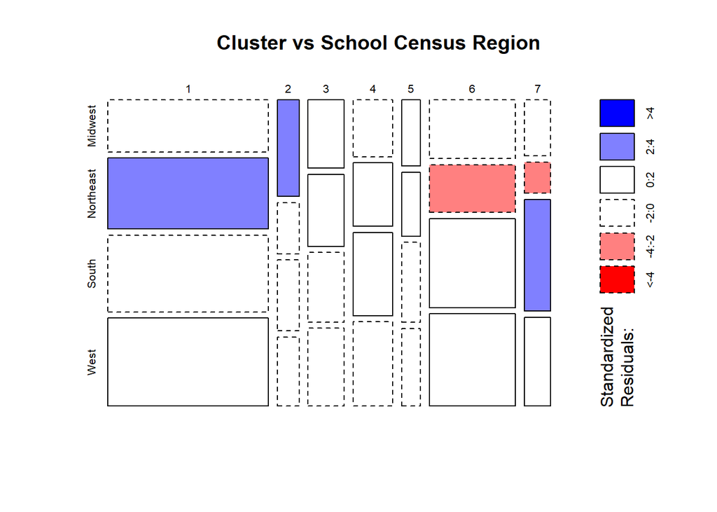

##### Distribution of clusters among census division location of schools

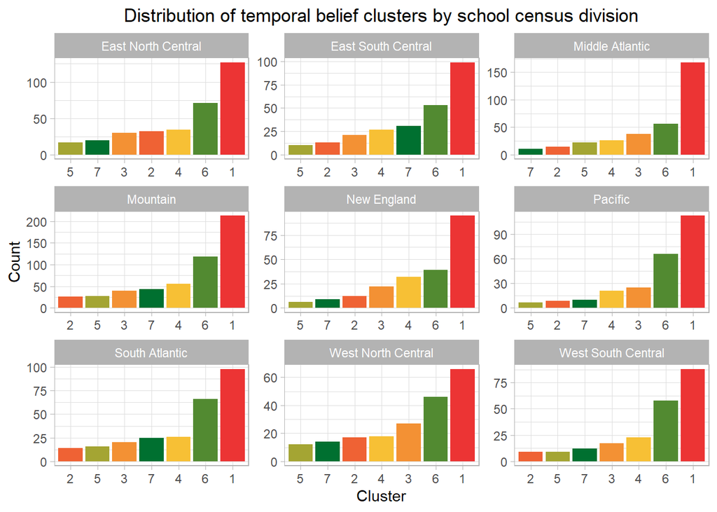

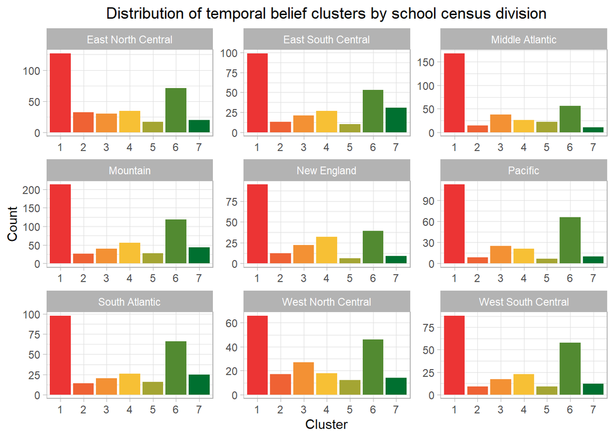

Chi square test of cluster by school census division location

| division_name_school | n |
| --- | --- |
| East North Central | 331 |
| East South Central | 254 |
| Middle Atlantic | 334 |
| Mountain | 524 |
| New England | 215 |
| Pacific | 251 |
| South Atlantic | 265 |
| West North Central | 200 |
| West South Central | 216 |

```
##
##     East North Central East South Central Middle Atlantic Mountain New England
##   1                127                 99             168      213          95
##   2                 32                 13              14       26          12
##   3                 30                 21              38       40          22
##   4                 34                 27              26       56          32
##   5                 17                 10              22       27           6
##   6                 71                 53              56      118          39
##   7                 20                 31              10       44           9
##
##     Pacific South Atlantic West North Central West South Central
##   1     113             98                 66                 88
##   2       9             14                 17                  9
##   3      25             20                 27                 17
##   4      21             26                 18                 23
##   5       7             16                 12                  9
##   6      66             66                 46                 58
##   7      10             25                 14                 12
```

```
##
##  Pearson's Chi-squared test
##
## data:  cont_table_division
## X-squared = 95.611, df = 48, p-value = 5.305e-05
```

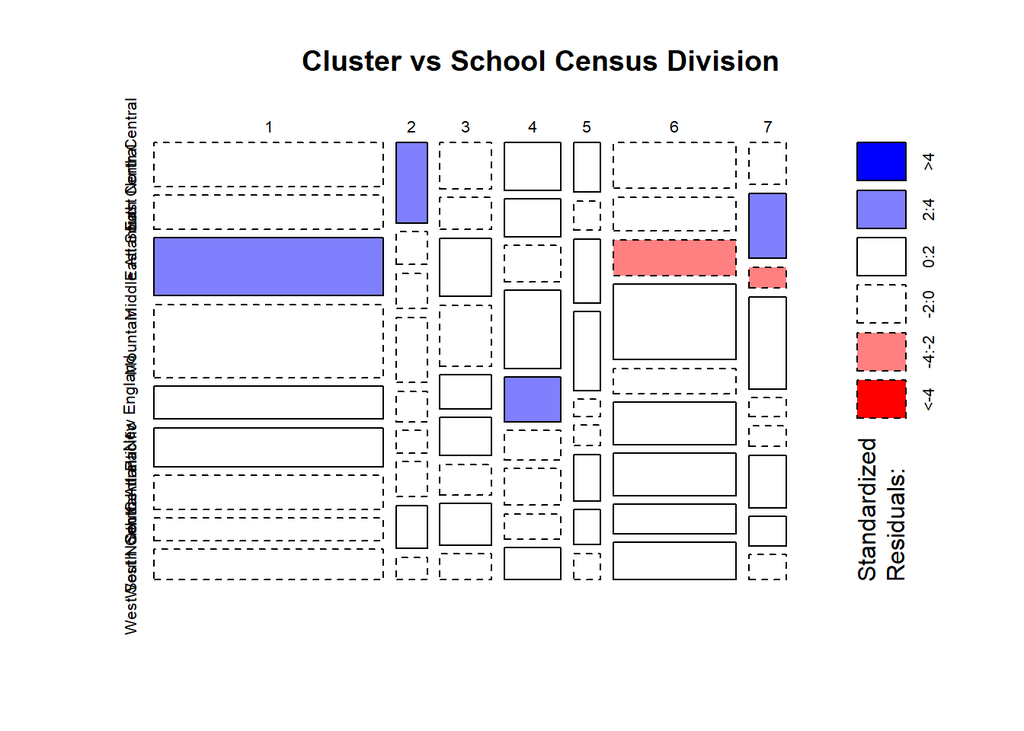

Follow up question: how many students move to a new census region or division for school?

| switch_state | n |
| --- | --- |
| Stay | 1964 |
| Switch | 597 |

| switch_division | n |
| --- | --- |
| Stay | 2181 |
| Switch | 380 |

| switch_region | n |
| --- | --- |
| Stay | 2302 |
| Switch | 259 |